# SU_25_River_Rockfish_Proj_V0.7

```r
ggsave(filename = "data-images/glu_ambient_boxplot.pdf", plot = glu_ambient_boxplot, device = "pdf")
ggsave(filename = "data-images/glu_ambient_boxplot.png", plot = glu_ambient_boxplot, device = "png")
```

Glucose Parametric Assessment Data Distribution

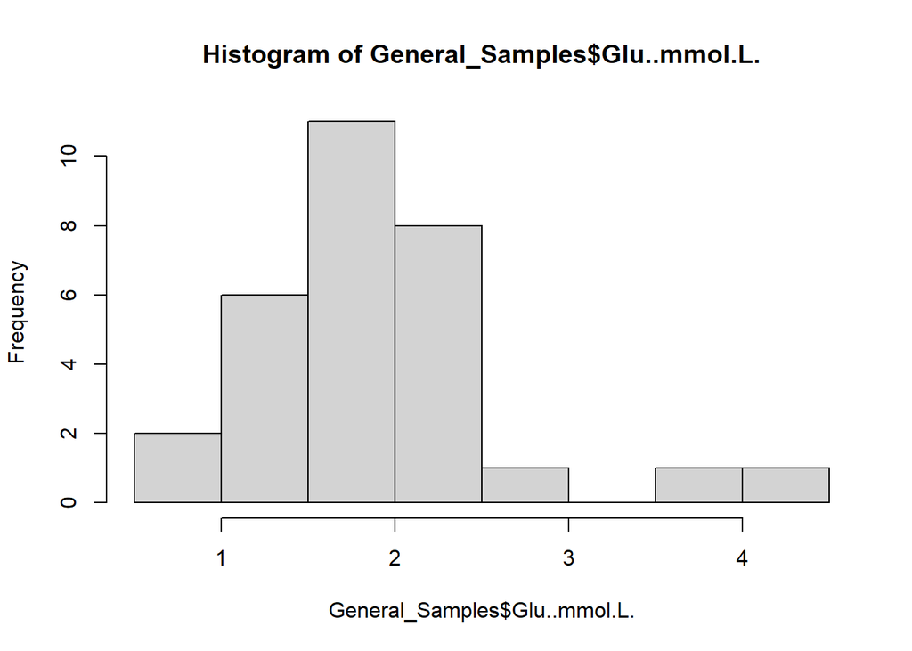

```r
# Glucose
# Parametric Assumptions

# Data Distribution

# Frequency Histograms

hist(General_Samples$Glu..mmol.L.)
```

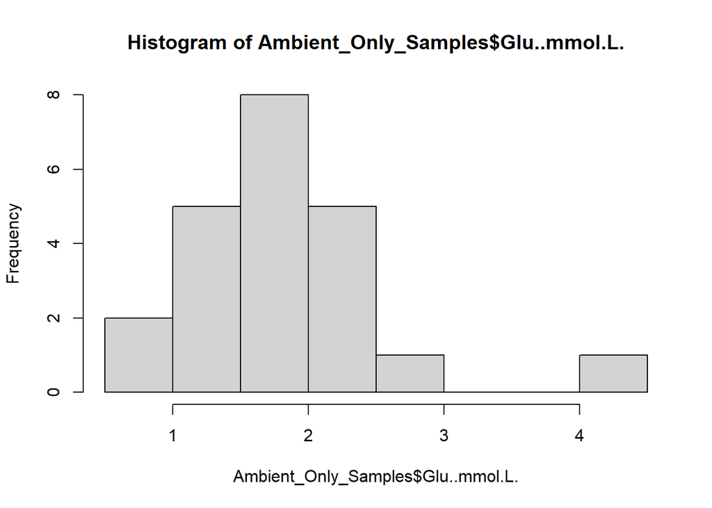

```r
hist(Ambient_Only_Samples$Glu..mmol.L.)
```

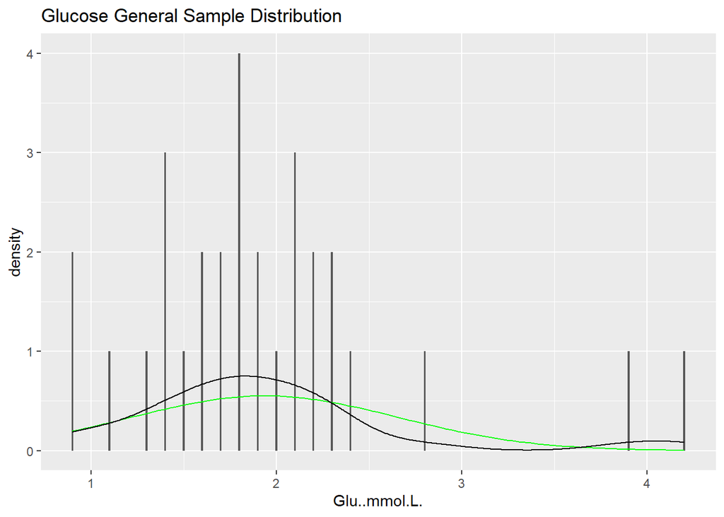

```r
# Density Histogram

# Density vs normality curve histograms
# Notes: Maybe set geom_density(alpha = 0.5)?

General_Samples %>%
  ggplot(aes(x = Glu..mmol.L.)) +
  geom_histogram(binwidth = 0.01) +
  stat_function(fun = dnorm, args = c(mean = mean(General_Samples$Glu..mmol.L.), sd = sd(General_Samples$Glu..mmol.L.)), col = "green") +
  geom_density(col = "black") +
  labs(title = "Glucose General Sample Distribution")
```

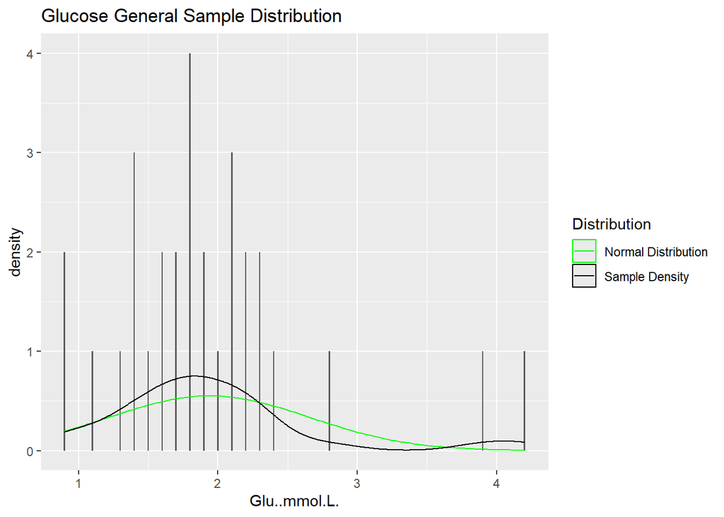

```r
# With legend label
General_Samples %>%
  ggplot(aes(x = Glu..mmol.L.)) +
  geom_histogram(binwidth = 0.01) +
  stat_function(fun = dnorm, args = c(mean = mean(General_Samples$Glu..mmol.L.), sd = sd(General_Samples$Glu..mmol.L.)), aes(col = "Normal Distribution"), show.legend = TRUE) +
  geom_density(aes(col = "Sample Density"), show.legend = TRUE) +
  labs(title = "Glucose General Sample Distribution") +
  scale_color_manual("Distribution", values = c("Normal Distribution" = "green", "Sample Density" = "black"))
```

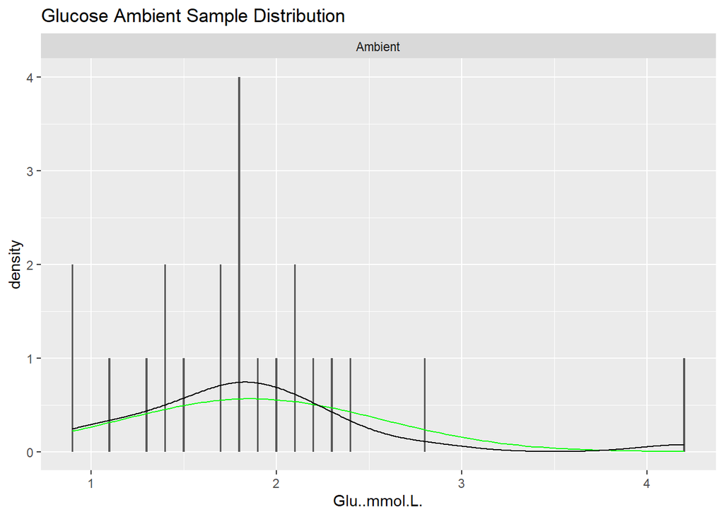

```r
Ambient_Only_Samples %>%
  ggplot(aes(x = Glu..mmol.L.)) +
  geom_histogram(binwidth = 0.01) +
  stat_function(fun = dnorm, args = c(mean = mean(Ambient_Only_Samples$Glu..mmol.L.), sd = sd(Ambient_Only_Samples$Glu..mmol.L.)), col = "green") +
  geom_density(col = "black") +
  facet_grid(~ Ambient.Or.OAH) +
  labs (title = "Glucose Ambient Sample Distribution")
```

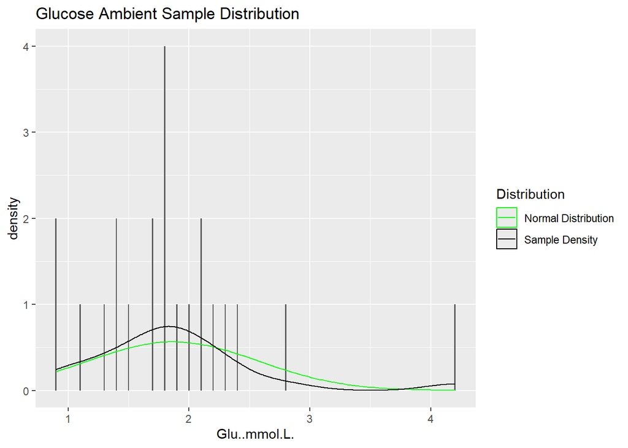

```r
# With legend label
Ambient_Only_Samples %>%
  ggplot(aes(x = Glu..mmol.L.)) +
  geom_histogram(binwidth = 0.01) +
  stat_function(fun = dnorm, args = c(mean = mean(Ambient_Only_Samples$Glu..mmol.L.), sd = sd(Ambient_Only_Samples$Glu..mmol.L.)), aes(col = "Normal Distribution"), show.legend = TRUE) +
  geom_density(aes(col = "Sample Density"), show.legend = TRUE) +
  labs(title = "Glucose Ambient Sample Distribution") +
  scale_color_manual("Distribution", values = c("Normal Distribution" = "green", "Sample Density" = "black"))
```

Review of Data Distribution (Data normally distributed?)

General data:

Ambient data:

Glucose Parametric Assessment General Normality Residual QQplot

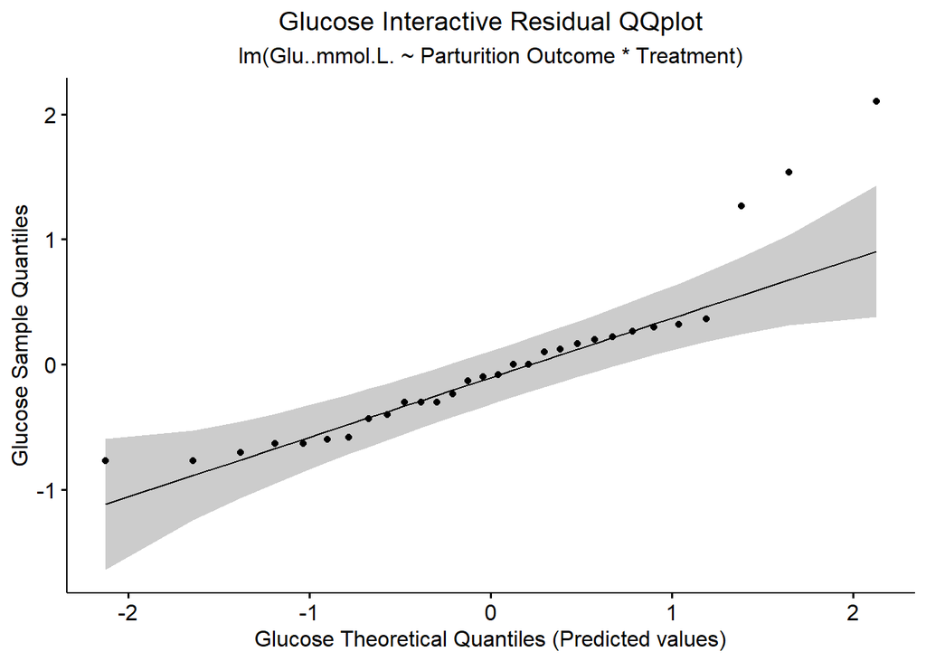

```r
# Glucose
# Parametric Assumptions:

# Assessing Normality
# Normality Plots
# Note: If data is non-normal considering applying transformation

# lm model of general data
glu_lm_int <- lm(Glu..mmol.L. ~ Pregnant.Or.Atresia * Ambient.Or.OAH, data = General_Samples)

# View all residual plots
#plot(glu_lm_int)

glu_res_int_qqplot <- ggqqplot(residuals(glu_lm_int)) +
labs(title = "Glucose Interactive Residual QQplot",
     subtitle = "lm(Glu..mmol.L. ~ Parturition Outcome * Treatment)",
                               x = "Glucose Theoretical Quantiles (Predicted values)",
                               y = "Glucose Sample Quantiles") +
  theme(plot.title = element_text(hjust = 0.5),
        plot.subtitle = element_text(hjust = 0.5))
print(glu_res_int_qqplot)
```

Review Normality Residual QQplot (normality conditions met?):

General data:

Glucose Parametric Assessment Ambient Normality Residual QQplot

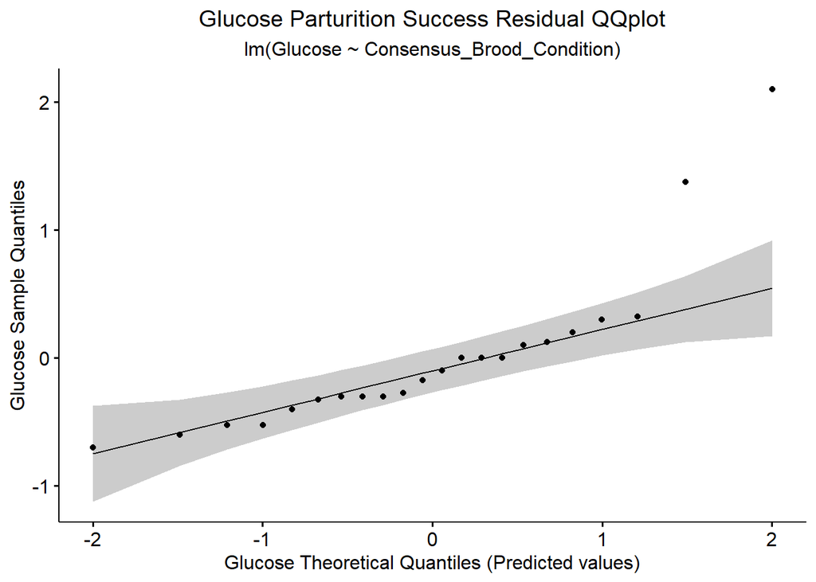

```r
# Glucose
# Parametric Assumptions

# Assessing Normality
# Normality Plots

# lm model of ambient data
glu_lm_ambient <- lm(Glu..mmol.L. ~ Consensus_Brood_Condition, data = Ambient_Only_Samples)

# View all residual plots
#plot(glu_lm_ambient)

glu_res_ambient_qqplot <- ggqqplot(residuals(glu_lm_ambient)) +
labs(title = "Glucose Parturition Success Residual QQplot",
     subtitle = "lm(Glucose ~ Consensus_Brood_Condition)",
                               x = "Glucose Theoretical Quantiles (Predicted values)",
                               y = "Glucose Sample Quantiles") +
  theme(plot.title = element_text(hjust = 0.5),
        plot.subtitle = element_text(hjust = 0.5))
print(glu_res_ambient_qqplot)
```

Review Normality Residual QQplot (normality conditions met?):

Ambient data:

Glucose Parametric Assessment Testing Normality

```r
# Glucose
# Parametric Assumptions

# Assessing Normality

# Analytical Test: Options listed below
# - Shapiro Test = for piping, shapiro_test() or in base r shapiro.test(): normal distribution

# Note: Shapiro test is sensitive to sample size, small n often pass normality, so review both visuals and test results to assess if normality conditions are met or not

# Note Error Message: error in `shapiro.test()`: ! sample size must be between 3 and 5000

# Shapiro.test for General Samples
General_Samples %>% shapiro_test(Glu..mmol.L.)
```

```
## # A tibble: 1 × 3
##   variable     statistic        p
##   <chr>            <dbl>    <dbl>
## 1 Glu..mmol.L.     0.858 0.000895
```

```r
General_Samples %>%
  group_by(Ambient.Or.OAH, Pregnant.Or.Atresia) %>%
  shapiro_test(Glu..mmol.L.)
```

```
## # A tibble: 4 × 5
##   Ambient.Or.OAH Pregnant.Or.Atresia variable     statistic       p
##   <chr>          <chr>               <chr>            <dbl>   <dbl>
## 1 Ambient        Atresia             Glu..mmol.L.     0.728 0.00107
## 2 Ambient        Post Parturition    Glu..mmol.L.     0.904 0.279
## 3 OAH            Atresia             Glu..mmol.L.     0.885 0.334
## 4 OAH            Post Parturition    Glu..mmol.L.     0.75  0
```

```r
# Shapito.test for Ambient Samples
Ambient_Only_Samples %>% shapiro_test(Glu..mmol.L.)
```

```
## # A tibble: 1 × 3
##   variable     statistic       p
##   <chr>            <dbl>   <dbl>
## 1 Glu..mmol.L.     0.869 0.00749
```

```r
# Ambient_Only_Samples %>%
#   group_by(Consensus_Brood_Condition) %>%
#   shapiro_test(Glu..mmol.L.)
```

Review of Shapiro-Wilk test (normality conditions met?):

General data:

Ambient data:

Glucose Parametric Assessment Testing Normality

```r
# Glucose
# Parametric Assumptions

# Assessing Normality

# Descriptive stat test: Stat.desc
# Z-score reflected in 'skew.2SE' and 'kurt.2SE'
# If these values are below 0.96 this indicates normality

# Note these values are sensitive to sample size, and are most effective for relatively small sample sizes approximately n = 30-50 range

# Note Alternative methods, all appear to display same results, not sure exactly how to incorporate an lm or aov model into the stat.desc function...

# General samples
General_Samples %>%
  summarise(Glu..mmol.L., Ambient.Or.OAH, Pregnant.Or.Atresia) %>%
  stat.desc(norm = TRUE)
```

```
##              Glu..mmol.L. Ambient.Or.OAH Pregnant.Or.Atresia
## nbr.val      3.000000e+01             NA                  NA
## nbr.null     0.000000e+00             NA                  NA
## nbr.na       0.000000e+00             NA                  NA
## min          9.000000e-01             NA                  NA
## max          4.200000e+00             NA                  NA
## range        3.300000e+00             NA                  NA
## sum          5.810000e+01             NA                  NA
## median       1.800000e+00             NA                  NA
## mean         1.936667e+00             NA                  NA
## SE.mean      1.319599e-01             NA                  NA
## CI.mean.0.95 2.698883e-01             NA                  NA
## var          5.224023e-01             NA                  NA
## std.dev      7.227740e-01             NA                  NA
## coef.var     3.732052e-01             NA                  NA
## skewness     1.440676e+00             NA                  NA
## skew.2SE     1.687399e+00             NA                  NA
## kurtosis     2.500267e+00             NA                  NA
## kurt.2SE     1.501219e+00             NA                  NA
## normtest.W   8.575214e-01             NA                  NA
## normtest.p   8.946882e-04             NA                  NA
```

```r
# Ambient samples
Ambient_Only_Samples %>%
  summarise(Glu..mmol.L., Brood_Condition) %>%
  stat.desc(norm = TRUE)
```

```
##              Glu..mmol.L. Brood_Condition
## nbr.val       22.00000000              NA
## nbr.null       0.00000000              NA
## nbr.na         0.00000000              NA
## min            0.90000000              NA
## max            4.20000000              NA
## range          3.30000000              NA
## sum           41.10000000              NA
## median         1.80000000              NA
## mean           1.86818182              NA
## SE.mean        0.15037995              NA
## CI.mean.0.95   0.31273222              NA
## var            0.49751082              NA
## std.dev        0.70534447              NA
## coef.var       0.37755665              NA
## skewness       1.43325879              NA
## skew.2SE       1.45964393              NA
## kurtosis       3.01939981              NA
## kurt.2SE       1.58452121              NA
## normtest.W     0.86897330              NA
## normtest.p     0.00749152              NA
```

Summary results of Glucose distribution (normality criteria met?):

General data:

Ambient data:

Glucose Parametric Assessment Assessing Scedasticity residual vs fitted plots

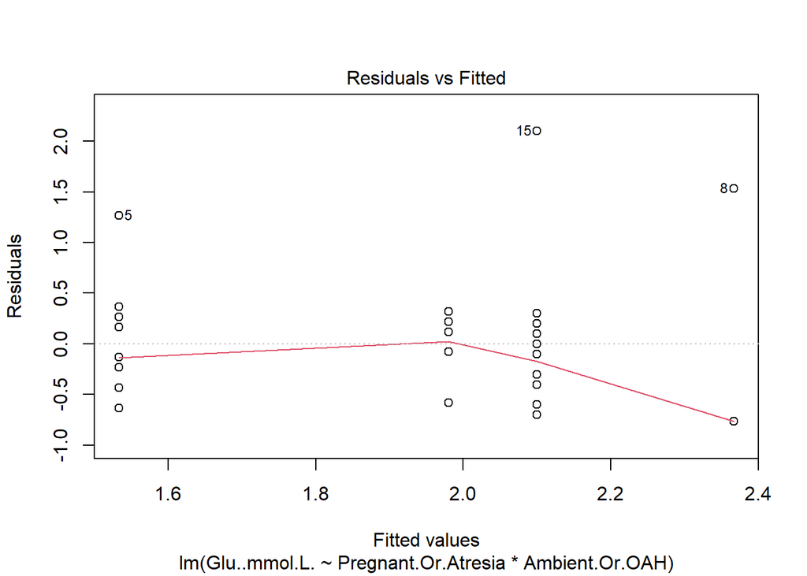

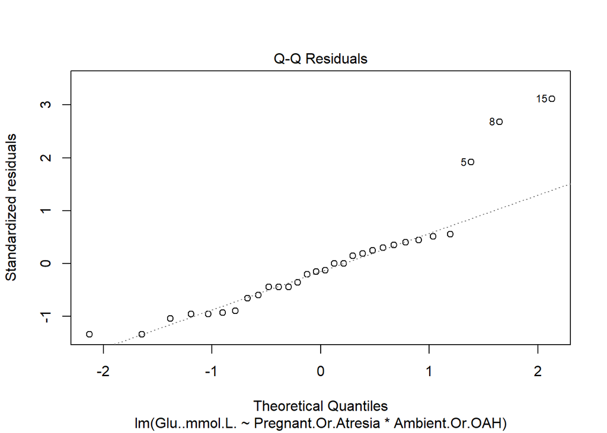

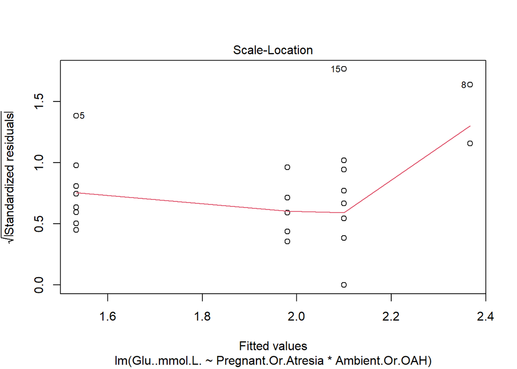

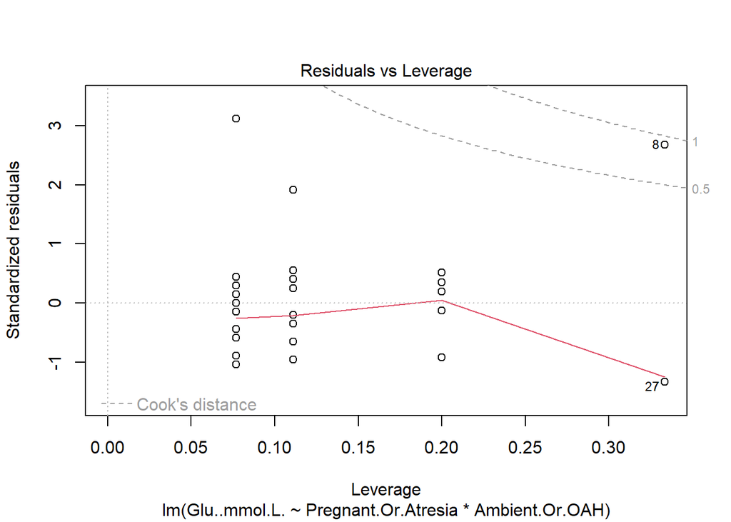

```r
# Glucose
# Parametric Assumptions
# Assessing Homoscedasticity: Equal Variance of Residuals

# Plotting residuals vs fitted

# Two-way ANOVA Interactive/Additive model: General factor comparison
lm(Glu..mmol.L. ~ Pregnant.Or.Atresia * Ambient.Or.OAH, data = General_Samples) %>% plot()
```

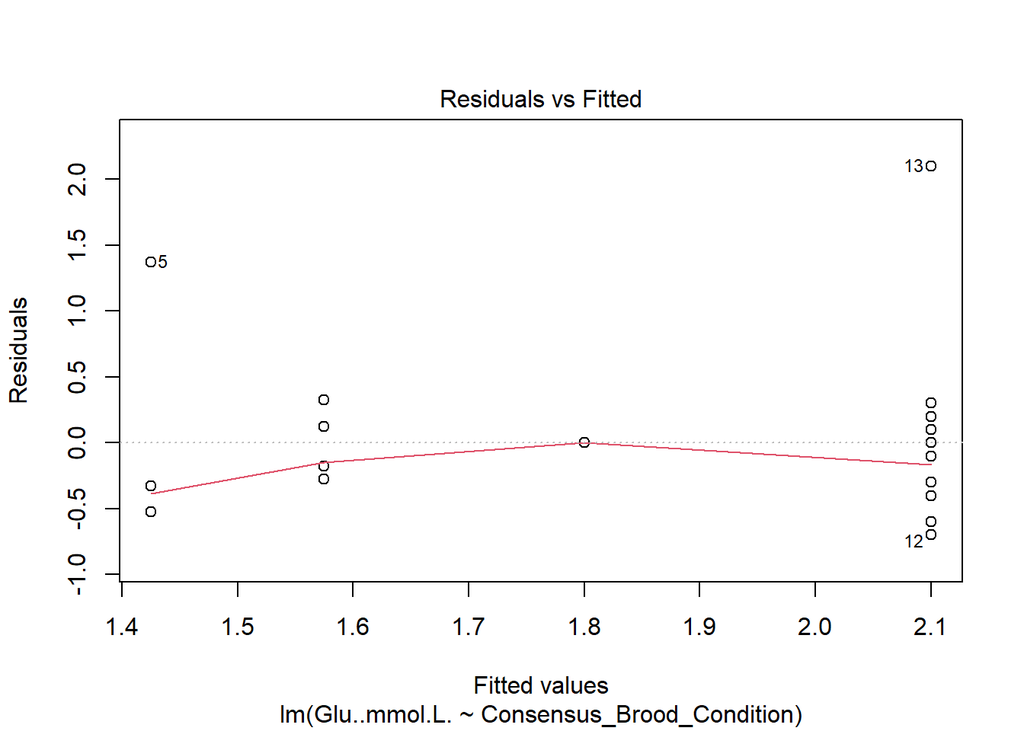

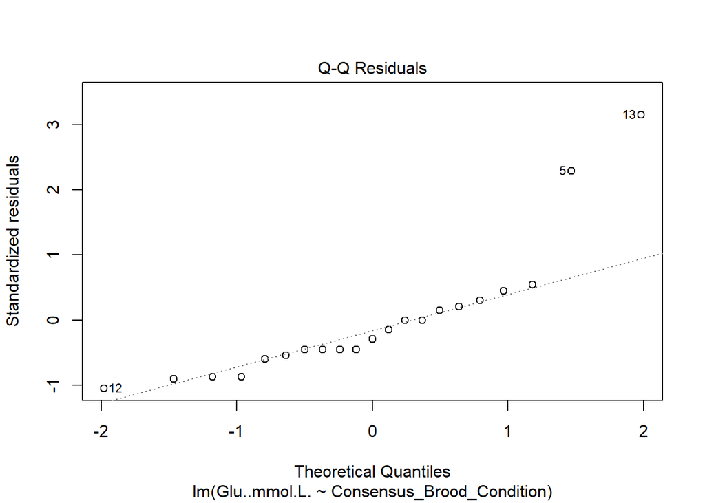

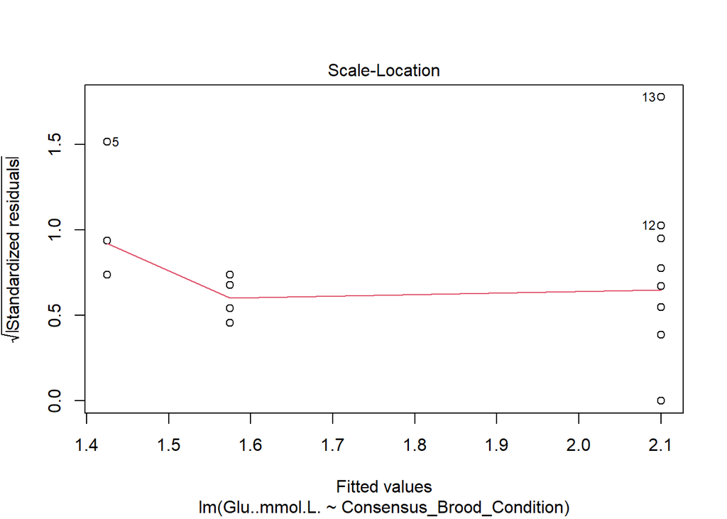

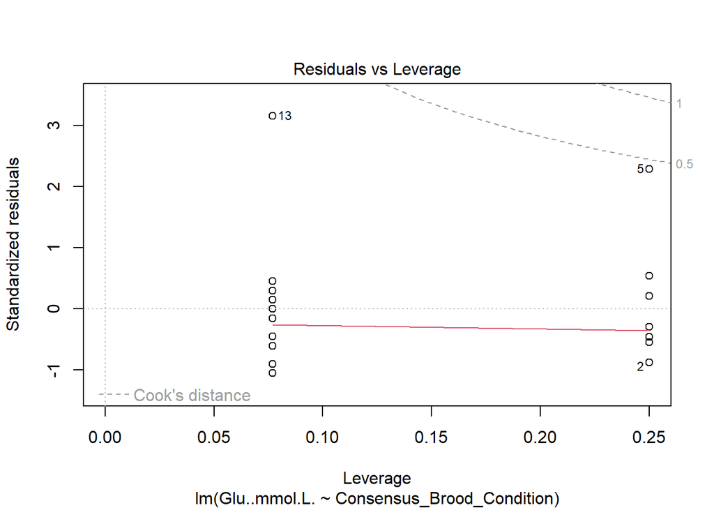

```r
# One-Way ANOVA model: Ambient Parturition Success comparison
lm(Glu..mmol.L. ~ Consensus_Brood_Condition, data = Ambient_Only_Samples) %>%
plot()
```

Review residual vs fitted plots (equal variance criteria met?):

General data:

Ambient data:

Glucose Parametric Assessment Scale Location Plot

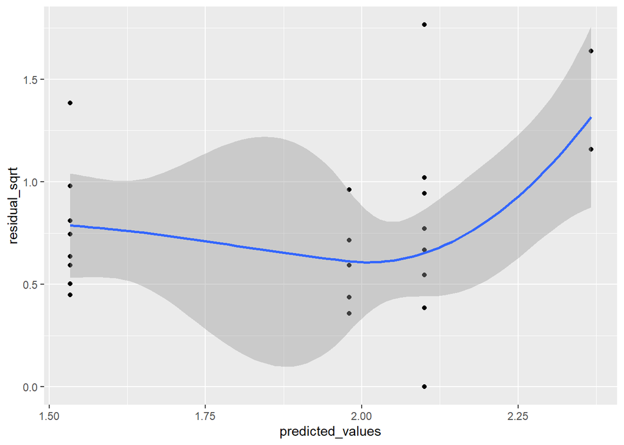

```r
# Glucose
# Scale location plot

# A flat line stat model is evidence of homoscedasticity, gentle or slight curves are generally accepted as equal variance across samples, however any large, drastic, or sharp changing features to the line suggest heteroscedasticity.
# The degree of slope of the stat model line to which we distinguish between equal or unequal variance across samples is unclear as of yet.


# Scale location plots
# General Samples

General_Samples %>%
  mutate(predicted_values = fitted(glu_lm_int),
         residual_sqrt = sqrt(abs(rstandard(glu_lm_int)))) %>%
  ggplot(aes(predicted_values, residual_sqrt)) +
  geom_point() +
  geom_smooth()
```

```
## `geom_line()`: Each group consists of only one observation.
## ℹ Do you need to adjust the group aesthetic?
```

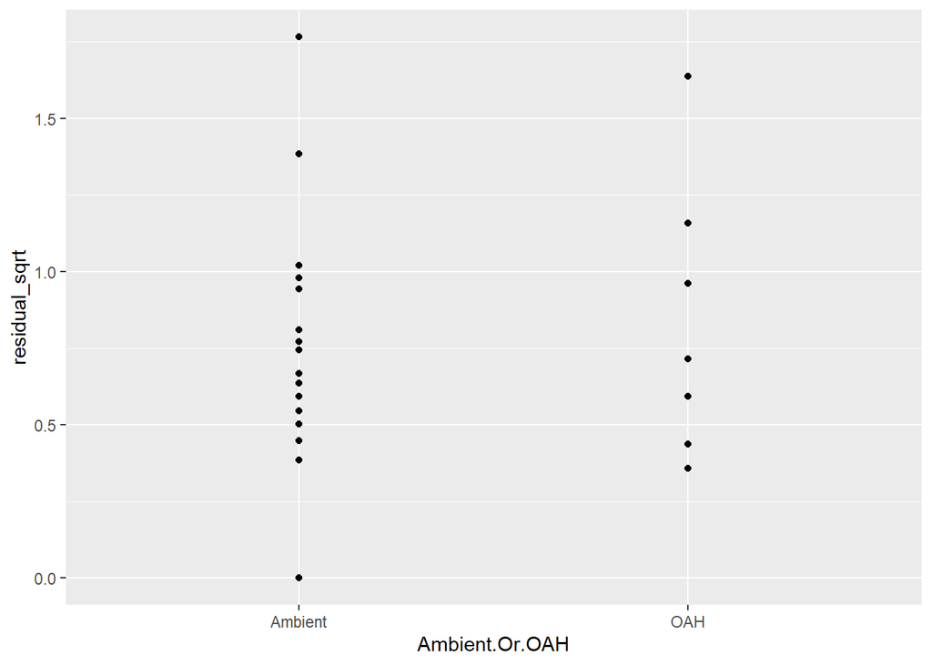

```r
# Compare residuals independently

# General treatment
General_Samples %>%
  mutate(predicted_values = fitted(glu_lm_int),
         residual_sqrt = sqrt(abs(rstandard(glu_lm_int)))) %>%
  ggplot(aes(Ambient.Or.OAH, residual_sqrt)) +
  geom_point() +
  stat_summary(geom = "line", fun = mean, color = "red")
```

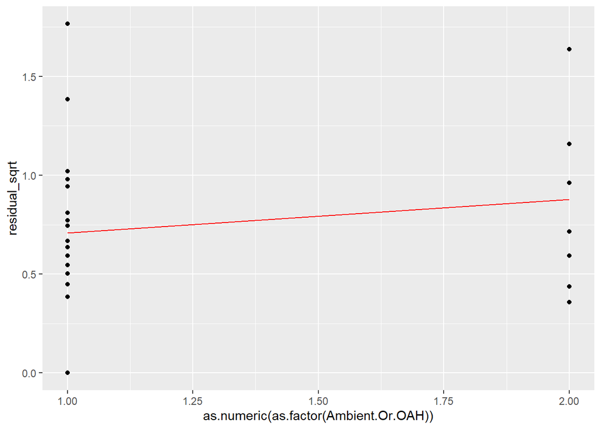

```r
General_Samples %>%
  mutate(predicted_values = fitted(glu_lm_int),
         residual_sqrt = sqrt(abs(rstandard(glu_lm_int)))) %>%
  ggplot(aes(as.numeric(as.factor(Ambient.Or.OAH)), residual_sqrt)) +
  geom_point() +
  stat_summary(geom = "line", fun = mean, color = "red")
```

```
## `geom_line()`: Each group consists of only one observation.
## ℹ Do you need to adjust the group aesthetic?
```

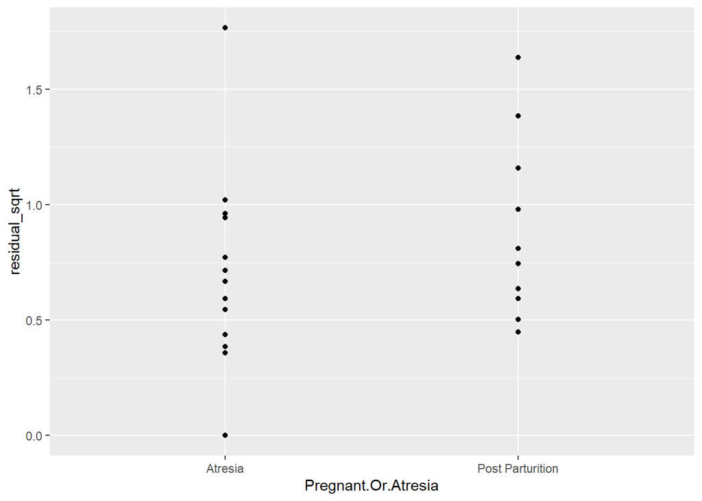

```r
# General parturition outcome
General_Samples %>%
  mutate(predicted_values = fitted(glu_lm_int),
         residual_sqrt = sqrt(abs(rstandard(glu_lm_int)))) %>%
  ggplot(aes(Pregnant.Or.Atresia, residual_sqrt)) +
  geom_point() +
  stat_summary(geom = "line", fun = mean, color = "red")
```

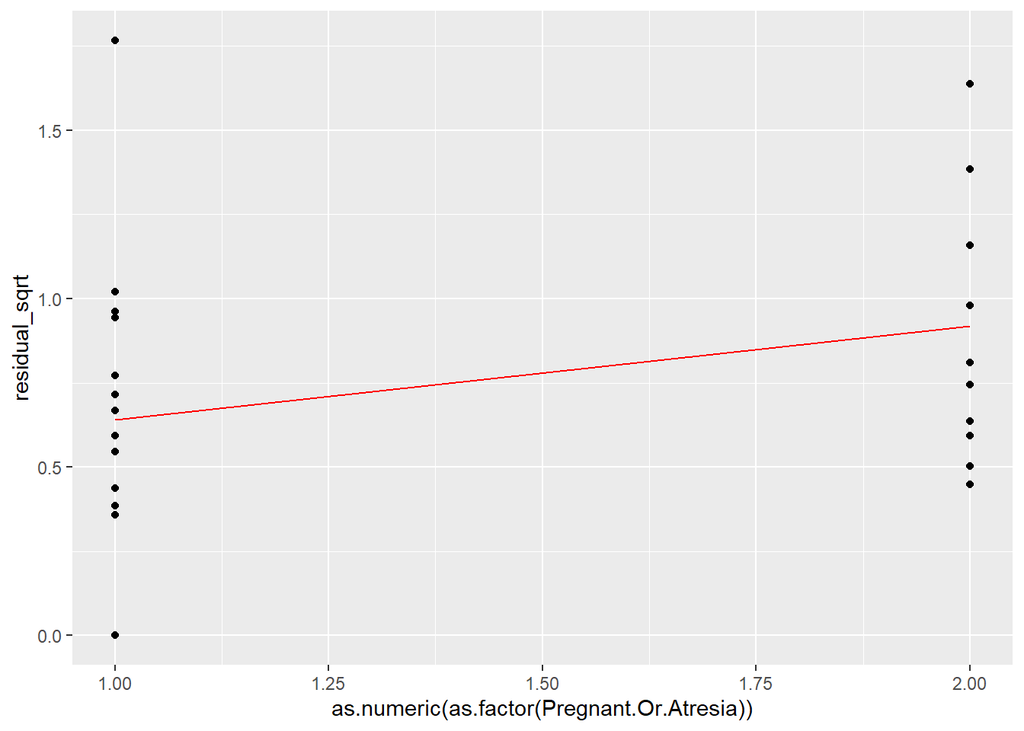

```r
General_Samples %>%
  mutate(predicted_values = fitted(glu_lm_int),
         residual_sqrt = sqrt(abs(rstandard(glu_lm_int)))) %>%
  ggplot(aes(as.numeric(as.factor(Pregnant.Or.Atresia)), residual_sqrt)) +
  geom_point() +
  stat_summary(geom = "line", fun = mean, color = "red")
```

Glucose Parametric Assessment Testing Scedasticity:

```r
# Glucose
# Parametric Assumptions
# Assessing Homoscedasticity: Equal Variance of Residuals

# Testing scedasticity: Options listed below
# - F-test = var.test(): For normally distributed data with two groups only)
# - Bartlett's test = bartlett.test(): For normally distributed data with multiple groups. Sensitive to normality)
# - Levene's Test = leveneTest(): Similar to Bartlett's test, but more robust to variance, less sensitive to normality)
# - Fligner-Killeen test = fligner.test(): A nonparametric test, made to be even more robust against non-normal distributed data
# - Breusch Pagan test = library(lmtest) + bptest(): test for scedasticity in linear regression models


# Bartlett's test
# Note Error Code: Requires at least 2 obs per group

# General samples
bartlett.test(Glu..mmol.L. ~ Ambient.Or.OAH, General_Samples)
```

```
##
##  Bartlett test of homogeneity of variances
##
## data:  Glu..mmol.L. by Ambient.Or.OAH
## Bartlett's K-squared = 0.11869, df = 1, p-value = 0.7305
```

```r
bartlett.test(Glu..mmol.L. ~ Pregnant.Or.Atresia, General_Samples)
```

```
##
##  Bartlett test of homogeneity of variances
##
## data:  Glu..mmol.L. by Pregnant.Or.Atresia
## Bartlett's K-squared = 1.4307, df = 1, p-value = 0.2317
```

```r
leveneTest(Glu..mmol.L. ~ Ambient.Or.OAH, General_Samples)
```

```
## Levene's Test for Homogeneity of Variance (center = median)
##       Df F value Pr(>F)
## group  1  0.0329 0.8574
##       28
```

```r
leveneTest(Glu..mmol.L. ~ Pregnant.Or.Atresia, General_Samples)
```

```
## Levene's Test for Homogeneity of Variance (center = median)
##       Df F value Pr(>F)
## group  1  0.7101 0.4065
##       28
```

```r
# Ambient samples

#bartlett.test(Glu..mmol.L. ~ Consensus_Brood_Condition, Ambient_Only_Samples)

leveneTest(Glu..mmol.L. ~ Consensus_Brood_Condition, Ambient_Only_Samples)
```

```
## Levene's Test for Homogeneity of Variance (center = median)
##       Df F value Pr(>F)
## group  3  0.3342 0.8008
##       18
```

Review Scedasticity tests (equal variance criteria met?):

General data:

Ambient data:

Summary results of glucose scedasticity (equal variance of residuals):

General data:

Ambient data:

Glucose Conclusions Parametric Assumptions Assessment:

General data:

Ambient data:

# Glucose Stat Tests

Glucose Statistical tests: Two-way anova with general data

```r
# Glucose Analysis
# ANOVA Tests

# Testing general factor differences: Treatment & Parturition Outcome
# Two-Way ANOVA

glu_aov_int <- aov(Glu..mmol.L. ~ Pregnant.Or.Atresia * Ambient.Or.OAH, data = General_Samples)
summary(glu_aov_int)
```

```
##                                    Df Sum Sq Mean Sq F value Pr(>F)
## Pregnant.Or.Atresia                 1  0.761  0.7605   1.548  0.225
## Ambient.Or.OAH                      1  0.355  0.3546   0.722  0.403
## Pregnant.Or.Atresia:Ambient.Or.OAH  1  1.260  1.2599   2.564  0.121
## Residuals                          26 12.775  0.4913
```

```r
# If Interaction not significant (p-value > 0.05), use additive model

glu_aov_additive <- aov(Glu..mmol.L. ~ Pregnant.Or.Atresia + Ambient.Or.OAH, data = General_Samples)
summary(glu_aov_additive)
```

```
##                     Df Sum Sq Mean Sq F value Pr(>F)
## Pregnant.Or.Atresia  1  0.761  0.7605   1.463  0.237
## Ambient.Or.OAH       1  0.355  0.3546   0.682  0.416
## Residuals           27 14.035  0.5198
```

```r
# Post-Hoc Test:
# - Tukey's HSD test (parametric)
# - Scheirer-Ray-Hare test (non-parametric)
# - Aligned Ranked Transformation (ART): Nonparametric, robust against violations to normality and homoscedasticity
# - Ordinal Logistic Regression

# Tukey's Honestly Significant Difference Test (Parametric):
glu_tukey_test <- TukeyHSD(glu_aov_int)
print(glu_tukey_test)
```

```
##   Tukey multiple comparisons of means
##     95% family-wise confidence level
##
## Fit: aov(formula = Glu..mmol.L. ~ Pregnant.Or.Atresia * Ambient.Or.OAH, data = General_Samples)
##
## $Pregnant.Or.Atresia
##                            diff        lwr       upr    p adj
## Post Parturition-Atresia -0.325 -0.8619645 0.2119645 0.224556
##
## $Ambient.Or.OAH
##                  diff        lwr       upr     p adj
## OAH-Ambient 0.2457386 -0.3491232 0.8406005 0.4035525
##
## $`Pregnant.Or.Atresia:Ambient.Or.OAH`
##                                                     diff        lwr       upr
## Post Parturition:Ambient-Atresia:Ambient      -0.5666667 -1.4005071 0.2671738
## Atresia:OAH-Atresia:Ambient                   -0.1200000 -1.1319152 0.8919152
## Post Parturition:OAH-Atresia:Ambient           0.2666667 -0.9649973 1.4983307
## Atresia:OAH-Post Parturition:Ambient           0.4466667 -0.6258951 1.5192285
## Post Parturition:OAH-Post Parturition:Ambient  0.8333333 -0.4486232 2.1152899
## Post Parturition:OAH-Atresia:OAH               0.3866667 -1.0176464 1.7909797
##                                                   p adj
## Post Parturition:Ambient-Atresia:Ambient      0.2676095
## Atresia:OAH-Atresia:Ambient                   0.9878280
## Post Parturition:OAH-Atresia:Ambient          0.9329985
## Atresia:OAH-Post Parturition:Ambient          0.6672448
## Post Parturition:OAH-Post Parturition:Ambient 0.3037621
## Post Parturition:OAH-Atresia:OAH              0.8735496
```

```r
glu_aov_int %>% tukey_hsd()
```

```
## # A tibble: 8 × 9
##   term   group1 group2 null.value estimate conf.low conf.high p.adj p.adj.signif
## * <chr>  <chr>  <chr>       <dbl>    <dbl>    <dbl>     <dbl> <dbl> <chr>
## 1 Pregn… Atres… Post …          0   -0.325   -0.862     0.212 0.225 ns
## 2 Ambie… Ambie… OAH             0    0.246   -0.349     0.841 0.404 ns
## 3 Pregn… Atres… Post …          0   -0.567   -1.40      0.267 0.268 ns
## 4 Pregn… Atres… Atres…          0   -0.120   -1.13      0.892 0.988 ns
## 5 Pregn… Atres… Post …          0    0.267   -0.965     1.50  0.933 ns
## 6 Pregn… Post … Atres…          0    0.447   -0.626     1.52  0.667 ns
## 7 Pregn… Post … Post …          0    0.833   -0.449     2.12  0.304 ns
## 8 Pregn… Atres… Post …          0    0.387   -1.02      1.79  0.874 ns
```

Glucose Statistical tests: One-way anova with ambient data

```r
# Glucose
# ANOVA Tests

# Testing for differences in ambient parturition success metrics
# One-way ANOVA (parametric) or Kruskal-Wallis test (nonparametric)

glu_aov_ambient <- aov(Glu..mmol.L. ~ Consensus_Brood_Condition, data = Ambient_Only_Samples)
summary(glu_aov_ambient)
```

```
##                           Df Sum Sq Mean Sq F value Pr(>F)
## Consensus_Brood_Condition  3  1.833  0.6109   1.276  0.312
## Residuals                 18  8.615  0.4786
```

```r
# Post-Hoc Test:
# - Tukey's HSD (parametric, normality & equal variance across groups)
# - Kruskal Wallis (nonparametric option)
# - Dunn's test (non-parametric, conduct after Kruskal-Wallis test)
```

## Glucose Summary

**Parameter Results Summary**: Deciding upon all evidence (data distribution, visuals, tests, parametric assumptions criteria met or not met): Assumptions, assumptions, assumptions…

Two-Way ANOVA Results (Comparing General Treatment and Parturition Outcome):

One-Way ANOVA Results (Comparing Ambient Parturition Success Metric):

# Na+ : Sodium

Sodium Summary Stats

```r
# Sodium: Na+
# Summary stats

# General data
General_Samples %>%
  group_by(Pregnant.Or.Atresia, Ambient.Or.OAH) %>%
  summarize(count = n(),
            median = round(median(Na...mmol.L.), 3),
            mean = round(mean(Na...mmol.L.), 3),
            sd = round(sd(Na...mmol.L.), 3),
            cv = round(sd(Na...mmol.L.)/mean(Na...mmol.L.), 3)) %>%
  ungroup()
```

```
## # A tibble: 4 × 7
##   Pregnant.Or.Atresia Ambient.Or.OAH count median  mean     sd    cv
##   <chr>               <chr>          <int>  <dbl> <dbl>  <dbl> <dbl>
## 1 Atresia             Ambient           13    178  181. 11.4   0.063
## 2 Atresia             OAH                5    174  174   2.24  0.013
## 3 Post Parturition    Ambient            9    176  176.  3.19  0.018
## 4 Post Parturition    OAH                3    178  178.  0.577 0.003
```

```r
# Ambient data
Ambient_Only_Samples %>%
  group_by(Ambient.Or.OAH, Consensus_Brood_Condition) %>%
  summarize(count = n(),
            median = round(median(Na...mmol.L.), 3),
            mean = round(mean(Na...mmol.L.), 3),
            sd = round(sd(Na...mmol.L.), 3),
            cv = round(sd(Na...mmol.L.)/mean(Na...mmol.L.), 3)) %>%
  ungroup()
```

```
## # A tibble: 4 × 7
##   Ambient.Or.OAH Consensus_Brood_Condition count median  mean    sd     cv
##   <chr>          <ord>                     <int>  <dbl> <dbl> <dbl>  <dbl>
## 1 Ambient        Excellent                     1   177   177  NA    NA
## 2 Ambient        Normal                        4   178.  177.  2.87  0.016
## 3 Ambient        Low                           4   176.  174   3.37  0.019
## 4 Ambient        Atresia                      13   178   181. 11.4   0.063
```

Sodium Boxplot

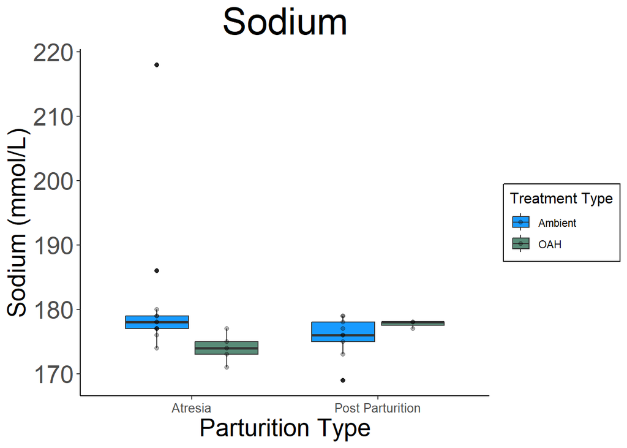

```r
# Sodium: Na+

# Sodium boxplot: General samples
sodium_general_boxplot <- ggplot(data = General_Samples, aes(x = Pregnant.Or.Atresia, y = Na...mmol.L., fill = Ambient.Or.OAH)) +
  geom_boxplot(aes(x = Pregnant.Or.Atresia, y = Na...mmol.L., fill = Ambient.Or.OAH)) +
  geom_point(aes(color = Ambient.Or.OAH), position = position_dodge(width = 0.75), alpha = 0.3, color = "black") +
  labs(title = "Sodium", x = "Parturition Type", y = "Sodium (mmol/L)") +
  guides(fill = guide_legend((title = "Treatment Type"))) +
  scale_fill_manual(values = c("Ambient" = "#189bff", "OAH" = "#598c78")) +
  theme_classic() +
  theme(panel.background = element_rect(fill = "white"),
        plot.background = element_rect(fill = "white"),
        legend.background = element_rect(fill = "white", color = "black"),
        title = element_text(size = 12),
        plot.title = element_text(size = 30, hjust = 0.5),
        axis.text.x = element_text(size = 10),
        axis.text.y = element_text(size = 20),
        axis.title.x = element_text(size = 20),
        axis.title.y = element_text(size = 20))

print(sodium_general_boxplot)
```

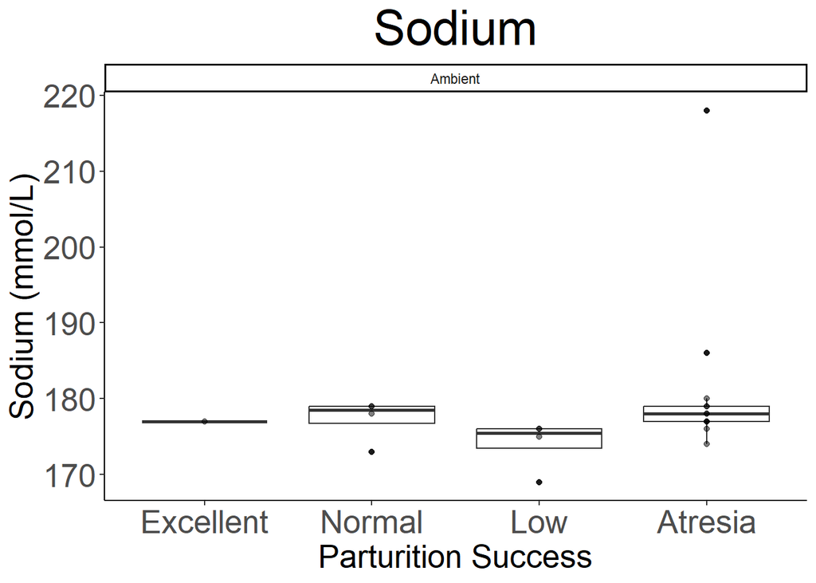

```r
ggsave(filename = "data-images/sodium_general_boxplot.pdf", plot = sodium_general_boxplot, device = "pdf")
ggsave(filename = "data-images/sodium_general_boxplot.png", plot = sodium_general_boxplot, device = "png")
# Sodium boxplot: Ambient Samples
sodium_ambient_boxplot <- ggplot(data = Ambient_Only_Samples) +
  geom_boxplot(aes(x = Consensus_Brood_Condition, y = Na...mmol.L.)) +
  geom_point(aes(x = Consensus_Brood_Condition, y = Na...mmol.L.), alpha = 0.5, colour = "black") +
  labs(title = "Sodium", x = "Parturition Success", y = "Sodium (mmol/L)") +
  facet_wrap(~ Ambient.Or.OAH) +
  theme_classic() +
  theme(panel.background = element_rect(fill = "white"),
        plot.background = element_rect(fill = "white"),
        legend.background = element_rect(fill = "white", color = "black"),
        title = element_text(size = 12),
        plot.title = element_text(size = 30, hjust = 0.5),
        axis.text.x = element_text(size = 20),
        axis.text.y = element_text(size = 20),
        axis.title.x = element_text(size = 20),
        axis.title.y = element_text(size = 20))

print(sodium_ambient_boxplot)
```

```r
ggsave(filename = "data-images/sodium_ambient_boxplot.pdf", plot = sodium_ambient_boxplot, device = "pdf")
ggsave(filename = "data-images/sodium_ambient_boxplot.png", plot = sodium_ambient_boxplot, device = "png")
```

Sodium Parametric Assessment Data Distribution

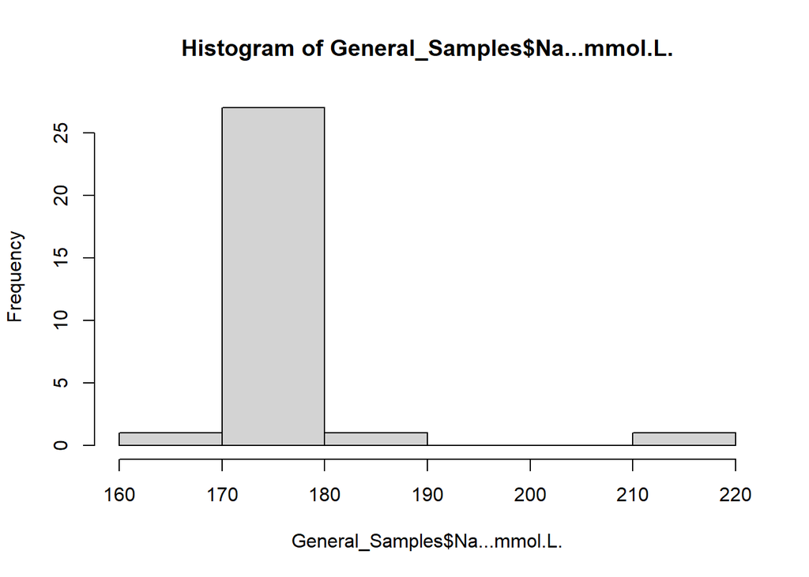

```r
# Sodium: Na+
# Parametric Assumptions

# Data Distribution

# Frequency Histograms

hist(General_Samples$Na...mmol.L.)
```

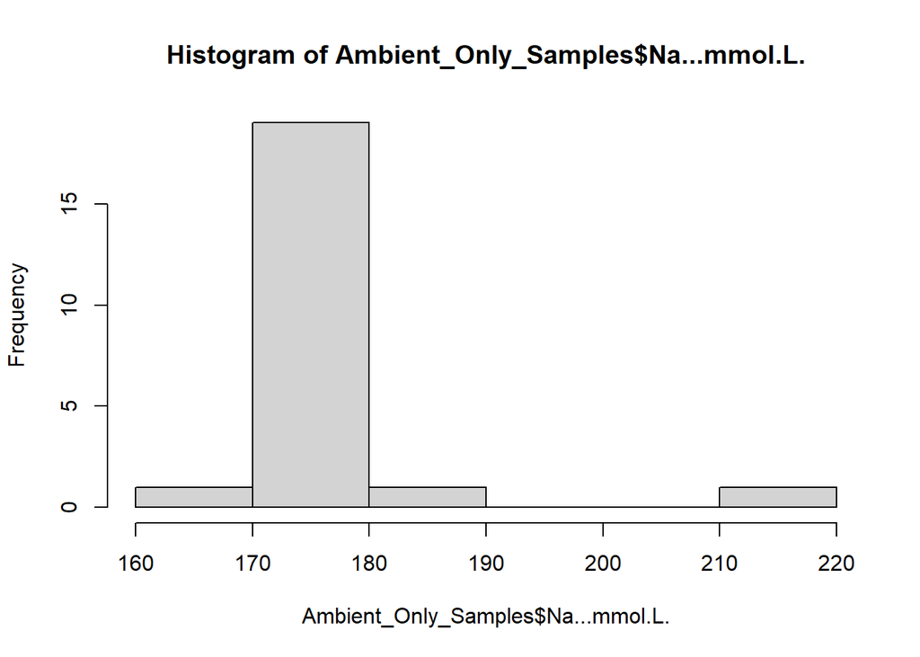

```r
hist(Ambient_Only_Samples$Na...mmol.L.)
```

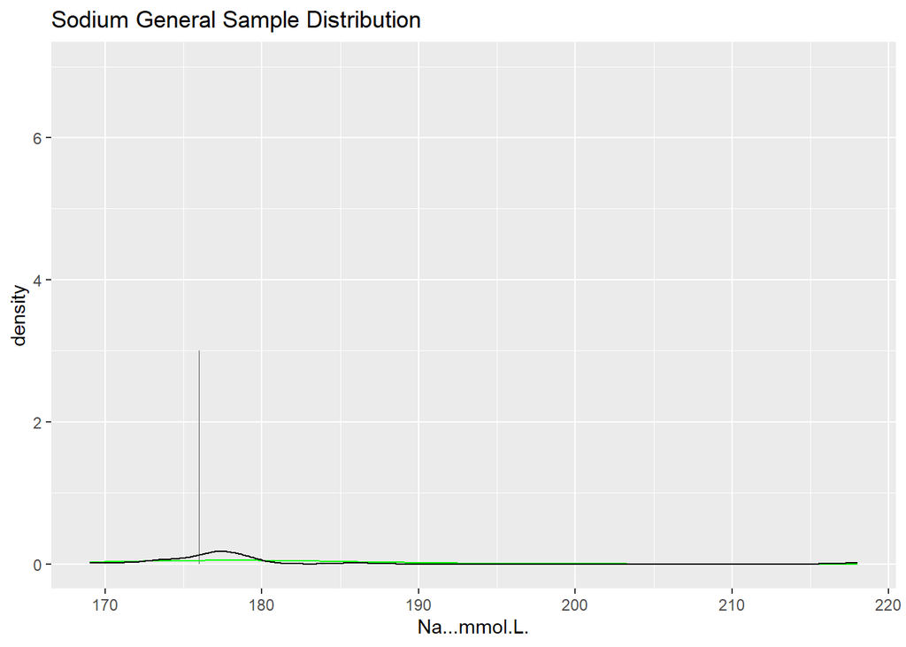

```r
# Density Histogram

# Density vs normality curve histograms
# Notes: Maybe set geom_density(alpha = 0.5)?

General_Samples %>%
ggplot(aes(x = Na...mmol.L.)) +
geom_histogram(binwidth = 0.01) +
stat_function(fun = dnorm, args = c(mean = mean(General_Samples$Na...mmol.L.), sd = sd(General_Samples$Na...mmol.L.)), col = "green") +
geom_density(col = "black") +
labs(title = "Sodium General Sample Distribution")
```

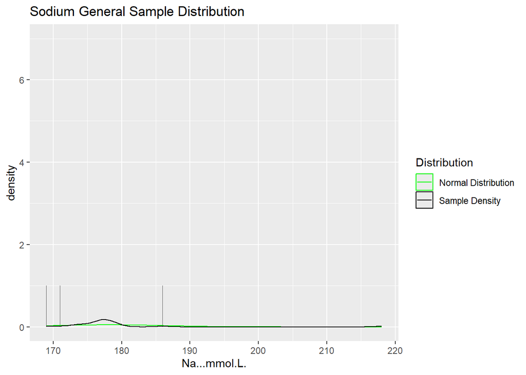

```r
# With legend label
General_Samples %>%
  ggplot(aes(x = Na...mmol.L.)) +
  geom_histogram(binwidth = 0.01) +
  stat_function(fun = dnorm, args = c(mean = mean(General_Samples$Na...mmol.L.), sd = sd(General_Samples$Na...mmol.L.)), aes(col = "Normal Distribution"), show.legend = TRUE) +
  geom_density(aes(col = "Sample Density"), show.legend = TRUE) +
  labs(title = "Sodium General Sample Distribution") +
  scale_color_manual("Distribution", values = c("Normal Distribution" = "green", "Sample Density" = "black"))
```

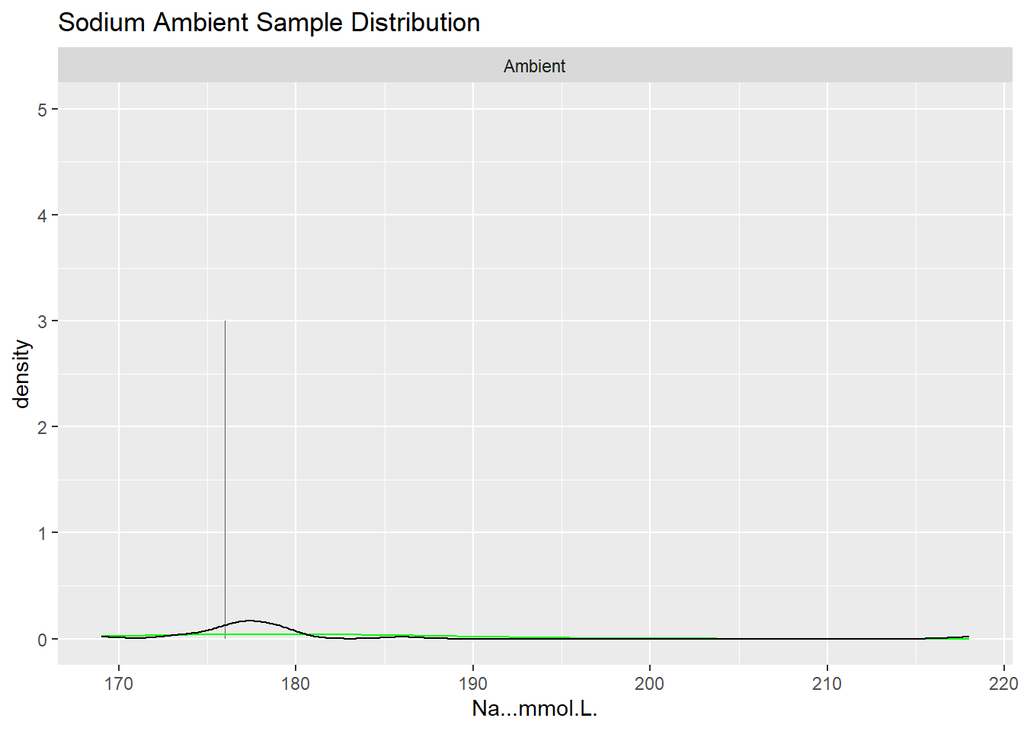

```r
# Ambient_Only_Samples %>%
Ambient_Only_Samples %>%
  ggplot(aes(x = Na...mmol.L.)) +
  geom_histogram(binwidth = 0.01) +
  stat_function(fun = dnorm, args = c(mean = mean(Ambient_Only_Samples$Na...mmol.L.), sd = sd(Ambient_Only_Samples$Na...mmol.L.)), col = "green") +
  geom_density(col = "black") +
  facet_grid(~ Ambient.Or.OAH) +
  labs (title = "Sodium Ambient Sample Distribution")
```

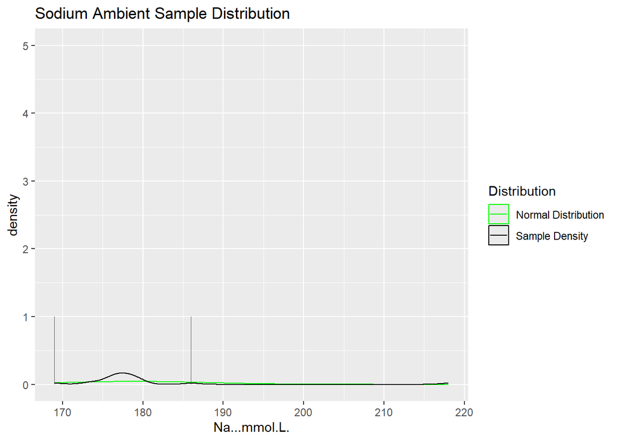

```r
# With legend label
Ambient_Only_Samples %>%
  ggplot(aes(x = Na...mmol.L.)) +
  geom_histogram(binwidth = 0.01) +
  stat_function(fun = dnorm, args = c(mean = mean(Ambient_Only_Samples$Na...mmol.L.), sd = sd(Ambient_Only_Samples$Na...mmol.L.)), aes(col = "Normal Distribution"), show.legend = TRUE) +
  geom_density(aes(col = "Sample Density"), show.legend = TRUE) +
  labs(title = "Sodium Ambient Sample Distribution") +
  scale_color_manual("Distribution", values = c("Normal Distribution" = "green", "Sample Density" = "black"))
```

Review of Data Distribution (Data normally distributed?)